# Big Sur Plot Network

- Workbook libraries, styles and classes  
- Plot disturbance grouping  
- Load raw tree database, add dummy variables for fire & p_ram presence  
- Add two dummy variables for failure and censor status based on genet/ramet  
- Add basal area  
- Course Woody Debris Analysis  
- Survival analysis dataframe  
- Link to modeling document

### Import

```python
#libraries
import pandas as pd
import numpy as np
import seaborn as sns
import matplotlib.pyplot as plt
from scipy import stats
from scipy.stats import f_oneway
from scipy.stats import tukey_hsd
from scipy.stats import linregress
from IPython.display import display
import statsmodels.api as sm
import statsmodels.api as sm
import statsmodels.formula.api as smf
from statsmodels.stats.anova import anova_lm
from sklearn.metrics import r2_score
#define cwd
import os
os.chdir('./sheets_calpoly')
print(os.getcwd())
```

```
C:\Users\benpa\Documents\juptyer\cal_poly\sheets_calpoly
```

```python
# presets
pd.set_option('display.max_colwidth', None)
sns.set_theme()
sns.set_theme(palette="colorblind", style="ticks")
pd.set_option('display.float_format', '{:.4f}'.format)
plt.rcParams.update({
    "font.family": "sans-serif",
    "font.sans-serif": ["Arial", "DejaVu Sans", "Verdana"],

})
#load and create dictionary of .csv data
bs_data = {'plot_data' : pd.read_csv('./plot_attributes.csv', encoding='latin1', low_memory=False),
          'tree_data' : pd.read_csv('./tree_data.csv', encoding='latin1', low_memory=False),
          'basal_species': pd.read_csv('./basalArea_trees.csv', encoding='latin1', low_memory=False),
          'stem_species': pd.read_csv('./basalArea_stemcount.csv', encoding='latin1', low_memory=False),
          'cwd_species': pd.read_csv('./basalArea_cwd.csv', encoding='latin1', low_memory=False),
          'plot_fire': pd.read_csv('./plot_fire.csv', encoding='latin1', low_memory=False)}
```

### Plot grouping

Need to better understand the different disturbances that have happened throughout the plot network, [dataset here](https://docs.google.com/spreadsheets/d/1v8svlbehpm1javFmeWQUJVsj88BfvcI0/edit?gid=250385454#gid=250385454).  
Plots will be grouped by: disturbance:

- fire (if so which one/combo) vs. control
- disease vs. control

topography:

- elevation
- slope

#### When were plots sampled? How many contain redwood?

```python
#load plot level data, clean irregularities
df_plot = bs_data['plot_data']
df_plot.columns = df_plot.iloc[0]
df_plot = df_plot.drop(df_plot.index[0]).reset_index()
df_plot.columns = df_plot.columns.str.strip()
df_inv = df_plot.filter(regex="(?i)Big Sur|year|forest|revisited|fully")
plot_stats = df_inv.iloc[:,0].nunique()
print("amount of plots established:")
display(plot_stats)
plot_revisit = df_inv.iloc[:,3].value_counts()
print("breakdown of how many plots have been revisited")
display(plot_revisit.head())
plot_fully = df_inv.iloc[:,4].value_counts()
print("how many plots have not been visited since 2009?")
display(plot_fully.head())
df_red_plot = df_inv.iloc[:,[0,2,3,4]]
df_f_type = df_red_plot[
    df_red_plot.iloc[:,1] == '2'
].iloc[:,1].value_counts()
print("how many plots are redwood?")
display(df_f_type.head())
df_red_count = df_red_plot[
    (df_red_plot.iloc[:,1] == '2')
    ].iloc[:,1:3].value_counts().reset_index(name='count')
print("How many plots have been revisited?")
display(df_red_count.head())
df_red_fully = df_red_plot[
    (df_red_plot.iloc[:,1] == '2')
    ].iloc[:,[1,3]].value_counts().reset_index(name='count')
print("how many of been visited since 2008?")
display(df_red_fully.head())
```

```
amount of plots established:
```

```
280
```

```
breakdown of how many plots have been revisited
```

```
Revisited since establishment (0=no; 1=yes)
1    171
0    109
Name: count, dtype: int64
```

```
how many plots have not been visited since 2009?
```

```
Not Fully Resurveyed since 2006/07 (excluding 08 & 09 survevys) 1=yes, 0=resurveyed recently
0    155
1    125
Name: count, dtype: int64
```

```
how many plots are redwood?
```

```
Forest Type (1= ME or 2= SESE)
2    114
Name: count, dtype: int64
```

```
How many plots have been revisited?
```

|  | Forest Type (1= ME or 2= SESE) | Revisited since establishment (0=no; 1=yes) | count |
| --- | --- | --- | --- |
| 0 | 2 | 1 | 84 |
| 1 | 2 | 0 | 30 |

```
how many of been visited since 2008?
```

|  | Forest Type (1= ME or 2= SESE) | Not Fully Resurveyed since 2006/07 (excluding 08 & 09 survevys) 1=yes, 0=resurveyed recently | count |
| --- | --- | --- | --- |
| 0 | 2 | 0 | 77 |
| 1 | 2 | 1 | 37 |

```
confirms query only 171 revisited from 2008 on-
breakdown of the amount of plots per year
```

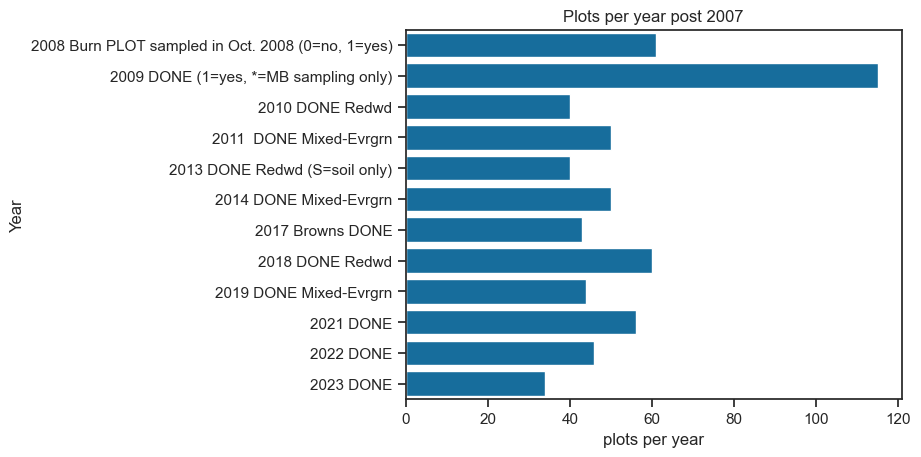

```python
df_year = df_plot.filter(regex="(?i)big sur|Original Sample|Oct. 2008|done")
df_year = df_year.rename(columns={
    df_year.columns[0] : 'BS_plot'
})
df_year_final = pd.melt(df_year, id_vars=['BS_plot'],  value_vars=df_year.iloc[:,2:], var_name='Year',
                        value_name='Yes/No')
df_year_final['Yes/No'].value_counts(dropna=False)
df_inv_year = df_year_final[
    df_year_final['Yes/No'] == '1'
    ]
confirm = df_inv_year['BS_plot'].nunique()
print(f"confirms query only 171 revisited from 2008 on-")
dfSum = df_inv_year.groupby('Year')['Yes/No'].size().reset_index(name='plots per year')
print("breakdown of the amount of plots per year")
sns.barplot(dfSum, y='Year', x='plots per year')
plt.title('Plots per year post 2007')
```

#### Disturbance grouping and distributions

Given data provided in the plot spreadsheet, add columns with fire scar boundary name, presence of p.ram, presence of fire.

```python
df_burnPlot = df_plot.filter(regex="(?i)Big Sur|burned|1st P.ram|elevation|slope|forest").iloc[:,[0,1,2,3,4,6,7,9]]
# isolate data for if burned and p.ram detection year
cols_to_convert = df_burnPlot.columns[1:]  # everything except first
# replace na with 0
df_burnPlot[cols_to_convert] = df_burnPlot[cols_to_convert].apply(pd.to_numeric, errors='coerce').fillna(0).astype(int)
# copy df for fire status, add fire status given values for burned 2008, 2016, 2020 binary
df_burn = df_burnPlot.copy()
col1 = df_burn.iloc[:,2]
col2 = df_burn.iloc[:,3]
col3 = df_burn.iloc[:,4]
conditions = [
    (col1 == 1) & (col2 == 0) & (col3 == 0),  # dolan
    (col1 == 0) & (col2 == 1) & (col3 == 0),  # sober
    (col1 == 0) & (col2 == 0) & (col3 == 1),  # chalk
    (col1 == 1) & (col2 == 0) & (col3 == 1),  # dolan_chalk
    (col1 == 0) & (col2 == 1) & (col3 == 1),  # sober_chalk
    (col1 == 0) & (col2 == 0) & (col3 == 0)   # control
]
labels = ['dolan', 'sober', 'chalk', 'dolan_chalk', 'sober_chalk', 'control']
df_burn['group'] = np.select(conditions, labels, default='unknown')
#rename columns
df_burn = df_burn.rename(columns = {
    df_burn.columns[0]: 'BS_plot',
    df_burn.columns[1]: 'Forest type',
    df_burn.columns[5]: 'elevation',
    df_burn.columns[6]: 'slope',
    df_burn.columns[7]: 'P_ram detection'})
df_burn.head()
```

|  | BS_plot | Forest type | burned 2020 | burned 2016 | burned 2008 | elevation | slope | P_ram detection | group |
| --- | --- | --- | --- | --- | --- | --- | --- | --- | --- |
| 0 | BS002 | 2 | 0 | 0 | 0 | 359 | 33 | 2018 | control |
| 1 | BS003 | 1 | 0 | 0 | 0 | 387 | 14 | 0 | control |
| 2 | BS004 | 1 | 0 | 0 | 0 | 778 | 35 | 0 | control |
| 3 | BS005 | 1 | 0 | 0 | 0 | 839 | 37 | 0 | control |
| 4 | BS006 | 1 | 0 | 0 | 0 | 800 | 33 | 0 | control |

```
now that burn scar is attached, we can see where the sites were visited each year post 2007 --
```

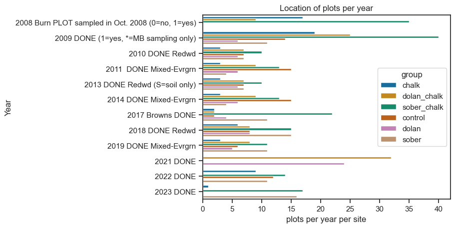

```python
dfYearBurn = pd.merge(df_inv_year, df_burn, on='BS_plot', how='left')
dfTot = dfYearBurn.groupby(['Year', 'group'])['Yes/No'].size().reset_index(name='plots per year per site')
print("now that burn scar is attached, we can see where the sites were visited each year post 2007 --")
sns.barplot(dfTot, x='plots per year per site', y='Year', hue='group')
plt.title("Location of plots per year")
plt.show()
```

### Load raw tree database, add dummy variables for fire & p_ram presence

Tree inventory dataset located [here](https://docs.google.com/spreadsheets/d/1HnFcAt-QIB9nOsEm94CMsk8XmoRtvoFf/edit?gid=1239576248#gid=1239576248).

```python
df_tree = bs_data['tree_data'].filter(regex="(?i)BS|stemid|species|Sample|DBH|status|\
basal|epicor|deadclass|logclass|snag|crown|health")
df_tree = df_tree.rename(columns={df_tree.columns[0]:'BS_plot'})
df_tree = df_tree.iloc[:,[0,1,12,2,3,4,5,6,13,16,17,18]].copy()
#make two columns for unique genet id and ramet id
df_tree[['GenetId', 'RametId']] = df_tree['StemID'].str.split('-', expand=True)
df_tree.head()
```

|  | BS_plot | Species | StemID | SampleYear | CrownPosition | HealthClass | BasalSprouts | EpicormicSprouts | DBH | Status | DeadClass | SnagHeight | GenetId | RametId |
| --- | --- | --- | --- | --- | --- | --- | --- | --- | --- | --- | --- | --- | --- | --- |
| 0 | BS002 | LIDE | 5169-1 | 2006 | I | 1.0000 | False | False | 10.2000 | L | NaN | NaN | 5169 | 1 |
| 1 | BS002 | LIDE | 5169-2 | 2006 | I | 1.0000 | False | False | 1.2000 | L | NaN | NaN | 5169 | 2 |
| 2 | BS002 | LIDE | 5169-3 | 2006 | I | 1.0000 | False | False | 1.4000 | L | NaN | NaN | 5169 | 3 |
| 3 | BS002 | LIDE | 5170-1 | 2006 | U | 1.0000 | True | False | 2.7000 | L | NaN | NaN | 5170 | 1 |
| 4 | BS002 | SESE | 5171-1 | 2006 | E | 1.0000 | True | False | 112.0000 | L | NaN | NaN | 5171 | 1 |

Descriptions for variables:

- crown position -- intermediate, understory, emergent, dominant, codominant, stump
- health class -- 1 is healthy, 2 fair, 3poor, 0dead no resprout, 5dead resprout,
- dead class --

```python
print(df_tree['CrownPosition'].unique())
print(df_tree['HealthClass'].unique())
print(df_tree['DeadClass'].unique())
```

```
['I' 'U' 'E' 'D' 'C' nan 'S']
[ 1.  2.  3.  5.  4.  6.  0. nan]
[nan 'C' 'B' '1' '2' '6' '3' 'A' '4' '7' '5' 'X' 'a']
```

```python
#merge plot data and tree data
treeDB = pd.merge(df_tree, df_burn, on='BS_plot', how='left')
#add dummy variable based on sample year, detection year
treeDB['p_ram presence'] = np.where(treeDB['SampleYear'] < treeDB['P_ram detection'], 0 , 1)
# add dummy variable based on sample year, burn scar
col1 = treeDB['SampleYear']
col2 = treeDB['group']
conditions = [
    (col2 == 'control'), #plots with control group have fire = 0
    #chalk, chalk_dolan, sober_chalk group
    (col1 > 2008) & (col2 == 'chalk'), # plots greater than 2008 have fire =1
    (col1 < 2008) & (col2 == 'chalk'),
    (col1 > 2008) & (col2 == 'dolan_chalk'), # plots greater than 2008 have fire =1
    (col1 < 2008) & (col2 == 'dolan_chalk'),
    (col1 > 2008) & (col2 == 'sober_chalk'), # plots greater than 2008 have fire =1
    (col1 < 2008) & (col2 == 'sober_chalk'),
    #sober group
    (col1 > 2016) & (col2 == 'sober'), # plots greater than 2016 have fire =1
    (col1 < 2016) & (col2 == 'sober'),
    # dolan, dolan chalk group
    (col1 > 2020) & (col2 == 'dolan'), # plots greater than 2020 have fire =1
    (col1 < 2020) & (col2 == 'dolan')
]
labels = ['0', '1', '0','1', '0', '1', '0', '1', '0', '1', '0']
treeDB['fire_presence'] = np.select(conditions, labels, default='unknown')
treeDB = treeDB.drop(['burned 2020', 'burned 2016', 'burned 2008'], axis=1)
dfTest = treeDB[
    (treeDB['group'] == 'dolan') & (treeDB['SampleYear'] > 2015)
    ]
print(f"testing to see if fire/p ram presence query was successful...\n This is the final dataset \
with plot and tree data linked.")
display(dfTest.head(2))
```

```
testing to see if fire/p ram presence query was successful...
 This is the final dataset with plot and tree data linked.
```

|  | BS_plot | Species | StemID | SampleYear | CrownPosition | HealthClass | BasalSprouts | EpicormicSprouts | DBH | Status | ... | SnagHeight | GenetId | RametId | Forest type | elevation | slope | P_ram detection | group | p_ram presence | fire_presence |
| --- | --- | --- | --- | --- | --- | --- | --- | --- | --- | --- | --- | --- | --- | --- | --- | --- | --- | --- | --- | --- | --- |
| 5448 | BS038 | UMCA | 6174-1 | 2021 | I | 4.0000 | True | False | 3.7000 | D | ... | NaN | 6174 | 1 | 2 | 553 | 33 | 2007 | dolan | 1 | 1 |
| 5449 | BS038 | UMCA | 6174-2 | 2021 | I | 4.0000 | True | False | 4.3000 | D | ... | NaN | 6174 | 2 | 2 | 553 | 33 | 2007 | dolan | 1 | 1 |

2 rows × 21 columns

### Add two dummy variables for failure and censor status based on genet/ramet

Assumptions:  
basal sprout = True for both genet and ramet  
if a ramet has died basal sprout = false  
Status class based on the ramet  
Tree numbers start from 1 and are not unique numbers from other plots For ramet fail status:

- Status D = 1
- All else = 0

```python
treeDB['RametFail'] = np.where(treeDB['Status'] == 'D', 1, 0)
deadBs = treeDB[
    (treeDB['Status'] == 'D') &
    (treeDB['BasalSprouts'] == False)
    ]
deadBs.head(2)
```

|  | BS_plot | Species | StemID | SampleYear | CrownPosition | HealthClass | BasalSprouts | EpicormicSprouts | DBH | Status | ... | GenetId | RametId | Forest type | elevation | slope | P_ram detection | group | p_ram presence | fire_presence | RametFail |
| --- | --- | --- | --- | --- | --- | --- | --- | --- | --- | --- | --- | --- | --- | --- | --- | --- | --- | --- | --- | --- | --- |
| 38 | BS002 | UMCA | 5184-11 | 2006 | I | 1.0000 | False | False | 1.5000 | D | ... | 5184 | 11 | 2 | 359 | 33 | 2018 | control | 0 | 0 | 1 |
| 44 | BS002 | UMCA | 5186-3 | 2006 | I | 2.0000 | False | False | 2.2000 | D | ... | 5186 | 3 | 2 | 359 | 33 | 2018 | control | 0 | 0 | 1 |

2 rows × 22 columns

Assumptions:  
Genet's can be tracked through the genet id column,  
genet's distinct remets can be found by multiple genet id rows with the genet id and different remet id.  
For a genet to die, all members of a unique tgenet id must have status = d

```python
#group by genet id, sampleyear, return series of status values,
#if all of series is D, then GenetFail= 1, if one of series is not D, GenetFail=0
genet_status = (
    treeDB.groupby(['GenetId','SampleYear'])['Status'].apply(lambda x: (x=='D').all())
        .astype(int).reset_index(name='GenetFail'))
surDB = pd.merge(treeDB, genet_status, on=['GenetId','SampleYear'], how='left')
print('check to see dead remet but genet lives on - remet fail 1 vs genet fail 0')
ind = surDB[
    (surDB['GenetFail'] == 0) &
    (surDB['RametFail'] == 1)
    ]
display(ind.head())
print('check to see dead genet - remet fail 1 vs genet fail 1')
indG = surDB[
    (surDB['GenetFail'] == 1) &
    (surDB['RametFail'] == 1)
    ]
display(indG.head())
```

```
check to see dead remet but genet lives on - remet fail 1 vs genet fail 0
```

|  | BS_plot | Species | StemID | SampleYear | CrownPosition | HealthClass | BasalSprouts | EpicormicSprouts | DBH | Status | ... | Forest type | elevation | slope | P_ram detection | group | p_ram presence | fire_presence | RametFail | BasalArea/Plot | GenetFail |
| --- | --- | --- | --- | --- | --- | --- | --- | --- | --- | --- | --- | --- | --- | --- | --- | --- | --- | --- | --- | --- | --- |
| 18 | BS002 | SESE | 5180-2 | 2006 | D | 1.0000 | True | False | 2.9000 | D | ... | 2 | 359 | 33 | 2018 | control | 0 | 0 | 1 | 0.0001 | 0.0000 |
| 38 | BS002 | UMCA | 5184-11 | 2006 | I | 1.0000 | False | False | 1.5000 | D | ... | 2 | 359 | 33 | 2018 | control | 0 | 0 | 1 | 0.0000 | 0.0000 |
| 44 | BS002 | UMCA | 5186-3 | 2006 | I | 2.0000 | False | False | 2.2000 | D | ... | 2 | 359 | 33 | 2018 | control | 0 | 0 | 1 | 0.0001 | 0.0000 |
| 80 | BS002 | UMCA | 5192-18 | 2006 | C | 1.0000 | False | False | 1.7000 | D | ... | 2 | 359 | 33 | 2018 | control | 0 | 0 | 1 | 0.0000 | 0.0000 |
| 129 | BS002 | SESE | 5173-2 | 2010 | E | 1.0000 | True | False | 6.9000 | D | ... | 2 | 359 | 33 | 2018 | control | 0 | 0 | 1 | 0.0005 | 0.0000 |

5 rows × 24 columns

```
check to see dead genet - remet fail 1 vs genet fail 1
```

|  | BS_plot | Species | StemID | SampleYear | CrownPosition | HealthClass | BasalSprouts | EpicormicSprouts | DBH | Status | ... | Forest type | elevation | slope | P_ram detection | group | p_ram presence | fire_presence | RametFail | BasalArea/Plot | GenetFail |
| --- | --- | --- | --- | --- | --- | --- | --- | --- | --- | --- | --- | --- | --- | --- | --- | --- | --- | --- | --- | --- | --- |
| 237 | BS002 | QUAG | 5200-1 | 2010 | U | 4.0000 | True | False | 1.2000 | D | ... | 2 | 359 | 33 | 2018 | control | 0 | 0 | 1 | 0.0000 | 1.0000 |
| 374 | BS002 | QUAG | 5200-1 | 2013 | U | 0.0000 | False | False | 1.4000 | D | ... | 2 | 359 | 33 | 2018 | control | 0 | 0 | 1 | 0.0000 | 1.0000 |
| 415 | BS002 | LIDE | 5182-1 | 2018 | I | 4.0000 | True | False | 9.8000 | D | ... | 2 | 359 | 33 | 2018 | control | 1 | 0 | 1 | 0.0010 | 1.0000 |
| 416 | BS002 | LIDE | 5182-2 | 2018 | I | 4.0000 | True | False | 8.0000 | D | ... | 2 | 359 | 33 | 2018 | control | 1 | 0 | 1 | 0.0007 | 1.0000 |
| 417 | BS002 | LIDE | 5183-1 | 2018 | C | 0.0000 | False | False | 25.1000 | D | ... | 2 | 359 | 33 | 2018 | control | 1 | 0 | 1 | 0.0069 | 1.0000 |

5 rows × 24 columns

### Add basal area

Add column with basal area derived from DBH, where:  
BA/tree = 0.005454 * (DBH)^2  
BA/plot = BA/ 500m2

```python
def ba(col):
    return((0.005454 * (col)**2)/500)
col = surDB['DBH']
surDB['BasalArea/Plot'] = ba(col)
surDB.head()
```

|  | BS_plot | Species | StemID | SampleYear | CrownPosition | HealthClass | BasalSprouts | EpicormicSprouts | DBH | Status | ... | Forest type | elevation | slope | P_ram detection | group | p_ram presence | fire_presence | RametFail | BasalArea/Plot | GenetFail |
| --- | --- | --- | --- | --- | --- | --- | --- | --- | --- | --- | --- | --- | --- | --- | --- | --- | --- | --- | --- | --- | --- |
| 0 | BS002 | LIDE | 5169-1 | 2006 | I | 1.0000 | False | False | 10.2000 | L | ... | 2 | 359 | 33 | 2018 | control | 0 | 0 | 0 | 0.0011 | 0.0000 |
| 1 | BS002 | LIDE | 5169-2 | 2006 | I | 1.0000 | False | False | 1.2000 | L | ... | 2 | 359 | 33 | 2018 | control | 0 | 0 | 0 | 0.0000 | 0.0000 |
| 2 | BS002 | LIDE | 5169-3 | 2006 | I | 1.0000 | False | False | 1.4000 | L | ... | 2 | 359 | 33 | 2018 | control | 0 | 0 | 0 | 0.0000 | 0.0000 |
| 3 | BS002 | LIDE | 5170-1 | 2006 | U | 1.0000 | True | False | 2.7000 | L | ... | 2 | 359 | 33 | 2018 | control | 0 | 0 | 0 | 0.0001 | 0.0000 |
| 4 | BS002 | SESE | 5171-1 | 2006 | E | 1.0000 | True | False | 112.0000 | L | ... | 2 | 359 | 33 | 2018 | control | 0 | 0 | 0 | 0.1368 | 0.0000 |

5 rows × 24 columns

```python
treeDB.to_csv('./treeDB.csv')
```

### Course Woody Debris Analysis

Add [cwd](https://docs.google.com/spreadsheets/d/1v8svlbehpm1javFmeWQUJVsj88BfvcI0/edit?gid=1537419783#gid=1537419783) to tree inventory dataset.

```python
cwdDB = bs_data['cwd_species']
cwdDB = cwdDB.rename(columns={cwdDB.columns[0]:'BS_plot'})
cwdDB = cwdDB.drop(['_'],axis=1)
cwdDB = pd.melt(cwdDB, id_vars=['BS_plot', 'SampleYear'], \
                var_name='Species_Decay', value_name='Volume/500m2 plot')
cwdDB[['Species', 'DecayClass']] = cwdDB['Species_Decay'].str.split('_', expand=True)
cwdDB = cwdDB.iloc[:,[0,1,-2,-1,-3]]
cwdDB = cwdDB[cwdDB['Volume/500m2 plot'] != 0]
cwdDB = cwdDB[(cwdDB['DecayClass'] != '7') & (cwdDB['DecayClass'] != '')]
display(cwdDB['DecayClass'].unique())
display(cwdDB.head())
```

```
array(['1', '2', '3', '4', '5'], dtype=object)
```

|  | BS_plot | SampleYear | Species | DecayClass | Volume/500m2 plot |
| --- | --- | --- | --- | --- | --- |
| 396 | BS296 | 2021 | ACMA | 1 | 0.3843 |
| 678 | BS048 | 2021 | ACMA | 2 | 0.2763 |
| 938 | BS233 | 2014 | ACMA | 2 | 0.7084 |
| 940 | BS233 | 2019 | ACMA | 2 | 0.7084 |
| 941 | BS233 | 2022 | ACMA | 2 | 0.7084 |

Using Dr.Cobb's [study](https://doi.org/10.1007/s10021-011-9506-y), get average density of decomposition classes.

```python
densityDB = pd.DataFrame({
    'DecayClass' : ['1','2','3','4','5'],
    'Density (g cm-3)' : [0.51, 0.48, 0.38, 0.24, 0.24]
})
densityDB.head()
```

|  | DecayClass | Density (g cm-3) |
| --- | --- | --- |
| 0 | 1 | 0.5100 |
| 1 | 2 | 0.4800 |
| 2 | 3 | 0.3800 |
| 3 | 4 | 0.2400 |
| 4 | 5 | 0.2400 |

```python
#merge cwd with density
cwdDB = pd.merge(cwdDB, densityDB, on='DecayClass', how='left')
cwdDB['Mass (tonnes)/plot'] = cwdDB.iloc[:,-2] * cwdDB.iloc[:,-1]
cwdDB.head()
```

|  | BS_plot | SampleYear | Species | DecayClass | Volume/500m2 plot | Density (g cm-3) | Mass (tonnes)/plot |
| --- | --- | --- | --- | --- | --- | --- | --- |
| 0 | BS296 | 2021 | ACMA | 1 | 0.3843 | 0.5100 | 0.1960 |
| 1 | BS048 | 2021 | ACMA | 2 | 0.2763 | 0.4800 | 0.1326 |
| 2 | BS233 | 2014 | ACMA | 2 | 0.7084 | 0.4800 | 0.3400 |
| 3 | BS233 | 2019 | ACMA | 2 | 0.7084 | 0.4800 | 0.3400 |
| 4 | BS233 | 2022 | ACMA | 2 | 0.7084 | 0.4800 | 0.3400 |

```python
print('comparing the amount of unique plots per dataset')
print(f'stem data: {treeDB['BS_plot'].nunique()}')
print(f'cwd data (no 2006/7): {cwdDB['BS_plot'].nunique()}')
```

```
comparing the amount of unique plots per dataset
stem data: 280
cwd data (no 2006/7): 153
```

**Things to consider... It seems like no cwd data in plots prior to 2009, therefore there is no pre Chalk fire data...**  
**What is the metrics of cwd volume? What are the final mass metrics?**

```python
print('sum the total mass per plot per year...')
cwdMass = cwdDB.groupby(['BS_plot', 'SampleYear'])['Mass (tonnes)/plot'].sum()\
    .reset_index(name='CWD Mass sum')
cwdMass.head()
```

```
sum the total mass per plot per year...
```

|  | BS_plot | SampleYear | CWD Mass sum |
| --- | --- | --- | --- |
| 0 | BS002 | 2022 | 0.8518 |
| 1 | BS016 | 2011 | 0.1623 |
| 2 | BS016 | 2014 | 0.2552 |
| 3 | BS020 | 2011 | 0.3136 |
| 4 | BS020 | 2014 | 0.2497 |

```python
# merge cwd to tree data, export
frankDB = pd.merge(surDB, cwdMass, on=['BS_plot', 'SampleYear'], how='left') #left merge to keep na
frankDB.head()
```

|  | BS_plot | Species | StemID | SampleYear | CrownPosition | HealthClass | BasalSprouts | EpicormicSprouts | DBH | Status | ... | elevation | slope | P_ram detection | group | p_ram presence | fire_presence | RametFail | BasalArea/Plot | GenetFail | CWD Mass sum |
| --- | --- | --- | --- | --- | --- | --- | --- | --- | --- | --- | --- | --- | --- | --- | --- | --- | --- | --- | --- | --- | --- |
| 0 | BS002 | LIDE | 5169-1 | 2006 | I | 1.0000 | False | False | 10.2000 | L | ... | 359 | 33 | 2018 | control | 0 | 0 | 0 | 0.0011 | 0.0000 | NaN |
| 1 | BS002 | LIDE | 5169-2 | 2006 | I | 1.0000 | False | False | 1.2000 | L | ... | 359 | 33 | 2018 | control | 0 | 0 | 0 | 0.0000 | 0.0000 | NaN |
| 2 | BS002 | LIDE | 5169-3 | 2006 | I | 1.0000 | False | False | 1.4000 | L | ... | 359 | 33 | 2018 | control | 0 | 0 | 0 | 0.0000 | 0.0000 | NaN |
| 3 | BS002 | LIDE | 5170-1 | 2006 | U | 1.0000 | True | False | 2.7000 | L | ... | 359 | 33 | 2018 | control | 0 | 0 | 0 | 0.0001 | 0.0000 | NaN |
| 4 | BS002 | SESE | 5171-1 | 2006 | E | 1.0000 | True | False | 112.0000 | L | ... | 359 | 33 | 2018 | control | 0 | 0 | 0 | 0.1368 | 0.0000 | NaN |

5 rows × 25 columns

```python
frankDB.to_csv('frank.csv')
```

### Survival analysis dataframe

Need new column, time since study start,  
where t = SampleYear - 2006  
Isolate only relevant data to survival analysis

```python
surDB['t'] = surDB['SampleYear'] - 2006
failDB = surDB[['BS_plot','Forest type', 'Species','GenetId','RametId','SampleYear', 't',\
    'RametFail','GenetFail', 'DBH', 'elevation', 'slope', 'group', 'p_ram presence', 'fire_presence']]
failDB.head()
```

|  | BS_plot | Forest type | Species | GenetId | RametId | SampleYear | t | RametFail | GenetFail | DBH | elevation | slope | group | p_ram presence | fire_presence |
| --- | --- | --- | --- | --- | --- | --- | --- | --- | --- | --- | --- | --- | --- | --- | --- |
| 0 | BS002 | 2 | LIDE | 5169 | 1 | 2006 | 0 | 0 | 0.0000 | 10.2000 | 359 | 33 | control | 0 | 0 |
| 1 | BS002 | 2 | LIDE | 5169 | 2 | 2006 | 0 | 0 | 0.0000 | 1.2000 | 359 | 33 | control | 0 | 0 |
| 2 | BS002 | 2 | LIDE | 5169 | 3 | 2006 | 0 | 0 | 0.0000 | 1.4000 | 359 | 33 | control | 0 | 0 |
| 3 | BS002 | 2 | LIDE | 5170 | 1 | 2006 | 0 | 0 | 0.0000 | 2.7000 | 359 | 33 | control | 0 | 0 |
| 4 | BS002 | 2 | SESE | 5171 | 1 | 2006 | 0 | 0 | 0.0000 | 112.0000 | 359 | 33 | control | 0 | 0 |

```python
failDB.to_csv('rawsurvival.csv')
```

#### Link to modeling document